# Chapter II - Sampling design comparison

Lise Fournier-Carnoy

1

Claude Spencer

1

Ben Radford

4

Stan Mastrantonis

3

Jordan Goetze

2

Matt Navarro

1

Tim Langlois

1

2025-02-26

# 1 Introduction

Anthropogenic stressors globally have caused significant declines in biodiversity, abundance and habitats (Isbell et al. 2023; Pereira et al. 2010). In the marine environment, increasing habitat loss has lead to biodiversity and biomass declines (Airoldi, Balata, and Beck 2008), increased the total area of dead zones, and lead to mass extinctions (Luypaert et al. 2020; McCauley et al. 2015). As a result, there has been a push for the creation and expansion of Marine Protected Areas (MPAs) and No-Take-Zones (NTZs) to safeguard biodiversity (Zhao, Ge, and Zheng 2024; Robinson et al. 2024): MPAs could provide resilience to changes driven by climate change in the medium-term by managing local stressors (Ling and Johnson 2012; Brown et al. 2013; Gissi et al. 2021). However, to better understand how MPAs affect species, habitats and ecosystems, and how they interact with local and global stressors, accurate monitoring is needed over adequate spatial and temporal scales (Borja and Elliott 2021). Correctly identifying the benefits of MPAs (or lack thereof) is therefore also critical to advise whether objectives are being met and ecosystems are adequately protected from local stressors (Miller and Russ 2014).

Many methods are used to monitor MPAs, depending on the biodiversity within them, the threats facing it, and the priorities identified by researchers (Simpson et al. 2015). The experimental designs used in monitoring have long been discussed, to ensure biological trends detected in the monitoring data are correctly attributed to the conservation intervention under study: Miteva, Pattanayak, and Ferraro (2012) review conservation instruments (including protected areas) and urge the need for better data to evaluate conservation interventions, to avoid drawing the wrong conclusions from monitoring data. In the past, studies assessing MPA effectiveness lacked controls and spatial/temporal replicates (Underwood 1991; Osenberg et al. 2006), which limited the power of monitoring. Improving experimental designs of MPA monitoring programmes will increase our ability to detect change and assess the effect and performance of MPAs on biological metrics (Hayes et al. 2019).

Spatial sampling design can result in large differences in estimates and outcomes depending on the sampling method used. For stock assessments of fished species (Liu, Chen, and Cheng 2009; Cheng et al. 2024) and underwater visual census of reef fish (Bryan et al. 2016; Smith et al. 2011), discussions as to how to distribute samples across a study area are common. Sample site choice can be separated into four broad categories: Systematic, Random, Preferential or Spatially Stratified. Systematic sampling effectively captures all scales (temporal or spatial) of a process, providing the most accurate estimates, (Cheng et al. 2024) although labour-intensive and rarely feasible in most contexts. Preferential sampling, a stochastically dependent method (i.e. selective site choice, Cecconi et al., 2016), greatly reduces costs while focusing on the process of interest. However, depending on the aim of sampling, the effect of selective bias on estimates may be significant, especially abundance (Aubry, Francesiaz, and Guillemain 2024; Conn, Thorson, and Johnson 2017), which is why Randomised sampling has been prevalent in research as a simple alternative. Stratified Random Sampling (referred hereafter as ‘spatially balanced’) seeks to randomly select sites equally between strata (shallow, mid-depth and deep, or seagrass, sand and reef habitats, for example) in an effort to obtain accurate relative abundance estimates for species of interest (Cheng et al. 2024), potentially improving on Preferential designs (Conn, Thorson, and Johnson 2017), while capturing a more representative population structure or community (Bryan et al. 2016) compared to Random sampling. Studies comparing sampling designs often operate at large spatial scales (100s of km, Cheng et al. (2024), Switzer et al. (2023)), investigating large biological processes like regional species abundance for fisheries stock assessments. At smaller spatial scales, sampling design is less studied: Bryan et al. (2016) found that obtaining precise estimates for inside/outside management zones like MPAs would require more samples rather than larger scales of study for stratified sampling, but few comparisons of sampling designs for the detection of MPA effects specifically exists. Similarly, very little work comparing BRUV performance using different sampling designs exists.

In Australia, Baited Remote Underwater Video (BRUVs) are widely used to monitor the effects of marine management like Marine Parks (MPAs) on abundance and size of communities and target species (Harasti et al. 2018; Kelaher et al. 2014; Malcolm et al. 2018). BRUVs present advantages compared to other common methods, including the ability to sample areas inaccessible by divers and more sensitive detection of changes in fish communities compared to other census methods (Schramm et al. 2020). The ability to use footage for a variety of research questions, including fish community (Watson et al. 2007), size (Malcolm et al. 2018; Watson et al. 2009), and habitat (Scott et al. 2022) make BRUVs a popular choice for researchers. Like any spatial sampling, the choice of where to deploy sampling units like BRUVs depends on the research question of interest (Foster et al. 2018), yet very few comparisons of BRUV spatial sampling designs exist to guide researchers.

This preliminary study aims to compare three BRUV spatial sampling designs at a local (<30km) scale, to understand how the detection of single and multiple species differ across a range of sampling designs from preferential to spatially balanced inside and near a NTZ. Real BRUV data is used to (1.) compare community composition, and (2.) simulate sampling designs on a modelled spatial distribution model of single species. Yijarup/Pink Snapper (*Chrysophrys auratus*) was chosen as a study species for (2.) as it is both a popular recreational fishing species (Ryan, Smallwood, and Lai 2022; Gaynor, Kendrick, and Westera 2008) as well as a species of interest to Wadandi Traditional Owners, who have intimate traditional knowledge of this species’ ecology and life history, cited in Wadandi cultural songlines (Davies et al. 2022). We hypothesised that (1.) Community composition would be significantly different between the sampling designs, with Spatially balanced sampling detecting a greater diversity of species, and that (2.) Spatially balanced sampling would detect NTZ abundance increases closer to the actual increase in abundance.

# 2 Methods

## 2.1 Study site and BRUV deployment

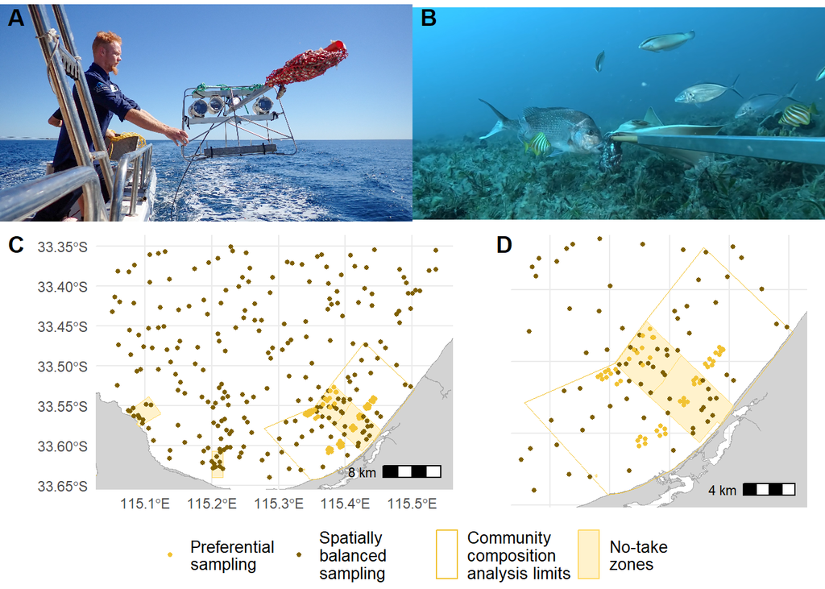

(#fig:real_BRUV_location)(A.) Wadandi Ranger Joe Burgess deploying a BRUV in Waatern/Geographe Bay. (B.) Yijarup/Pink Snapper (*C. auratus*), Eagle Ray (*M. tenuicaudatus*), Southern Maori Wrasse (*C. auricularis*), Skippy (*Pseudocaranx spp*) and Footballer Sweep (*N. obliiquus*) interested in BRUV bait. (C.) Location of preferential and spatially balanced samples in Waatern/Geographe Bay, with the NTZs and boundary of the community composition analysis. (D.) Community Composition analysis limits.

Waatern/Geographe Bay is a shallow sandy bay in Wadandi Country, ~250km south of Perth, in south-west Western Australia. (Figure @ref(fig:real_BRUV_location)) It represents a temperate ecosystem dominated by seagrass beds, sand and limestone reef (Galaiduk et al. 2018). The area contains three Sanctuary Zones (SZs) gazetted in 2018, covering 51.77km<sup>2</sup> of the bay. Fishing is excluded within the SZs.

Stereo Baited Remote Underwater Video (BRUV) footage was collected February-April 2024 as part of the state and federal Marine Park monitoring of Western Australia (Table @ref(tab:n_samples_table)). Deployments were conducted following standardised protocols for bait quantity and deployment times, used across Australia, which include calibration of the stereo systems before and after campaigns (Langlois et al. 2020). Wadandi Rangers and Cultural Custodian Elders were present and participated in the entirety of the BRUV deployments, informing the location of some of the preferential deployments. (Figure @ref(fig:real_BRUV_location))

(#tab:n_samples_table)BRUV Sampling Results

|  | Inside No-Take Area | Outside No-Take Area | Total |
| --- | --- | --- | --- |
| **a. Real BRUVs collected** |  |  |  |
| Preferential Sampling | 18 | 29 | 47 |
| Spatially Balanced Sampling (full data) | 45 | 191 | 236 |
| Spatially Balanced Sampling (subset data) | 27 | 25 | 52 |
| **b. Simulated BRUVs (clustered sampling design)** |  |  |  |
| Any strata | 16 | 32 | 48 |
| **c. Simulated BRUVs (preferential sampling design)** |  |  |  |
| Strata 3 (80-100% quantile) | 25 | 25 | 50 |
| **d. Simulated BRUVs (spatially balanced sampling design)** |  |  |  |
| Strata 1 (0-50% quantile) | 10 | 10 | 20 |
| Strata 2 (50-80% quantile) | 10 | 10 | 20 |
| Strata 3 (80-100% quantile) | 5 | 5 | 10 |

Real BRUVs were deployed according to two sampling designs: clustered sampling and spatially balanced sampling:

- Spatially balanced sampling aims to distribute sampling units randomly within strata of an environmental variable. This sampling design accounts for spatial heterogeneity and spatial autocorrelation (Kermorvant et al. 2019). More details on this sampling design is available further in section @ref(sec:SD_sim).
- Clustered sampling locations were sought out for the seabed complexity of the area, aiming to deploy BRUVs near highly complex sections, where many species tend to aggregate (Fernández et al. 2008). Deployments were either clustered around or aligned along seabed features (Figure @ref(fig:real_BRUV_location).

## 2.2 Data analysis

### 2.2.1 BRUV footage annotation

BRUV footage was annotated by research assistants trained in temperate Australian bony and cartilaginous fish species identification, to obtain MaxN (the greatest number of individuals of a species observed at one time in a deployment), lengths of individuals (possible through the stereo-video system), as well as habitat data (Langlois et al. 2020). Quality assurance was conducted through species identification cross-checking with other annotators, as well as through CheckEM (https://github.com/GlobalArchiveManual/CheckEM), a purpose-built application to compare identified species with their life histories and geographical ranges.

### 2.2.2 Effect of sampling design on the detection of community composition differences around a NTZ

The East Geographe NTZ (composed of National Park Zones and Sanctuary Zones) was used as a case study to assess whether the effect of marine protection on community composition was detected differently between sampling designs. This NTZ was the only area of the campaign where the inside and outside of the NTZ were sampled by both sampling designs. For this part of the analysis, spatially balanced points were subsampled to match the clustered sampling area (Figure @ref(fig:real_BRUV_location)). To investigate the difference in species composition between sampling designs, we conducted Principal Coordinate Analysis (PCoA; Bray-Curtis distances; vegan package, Oksanen et al. (2013)) and manyglm (negative binomial, adjusted p-values, mvabund package, Wang et al. (2012)), a generalised linear model framework for multivariate abundance data. Sampling design (clustered or spatially balanced) and status (NTZ or fished) were included in the model, to account for their potential effects on community composition (Scott et al. 2022; Watson et al. 2007). Habitat and depth were purposefully not included in the model as we considered them to be a sampling design choice: Bathymetry plays a major role in sampling design choice (see 2.2.3.3 below), and is also a strong contributor to habitat type and species distribution (Cameron et al. 2014). Assumptions of log-linearity, homoscedasticity and normality were confirmed prior to analysis.

### 2.2.3 Effect of sampling design on the detection of the NTZ effect of a single species

To compare the sampling designs’ ability to detect the effect of a NTZ on a single species, we conducted simulations of sampling designs on a modelled abundance distribution of Yijarup/Pink Snapper (*C. auratus*) around a simulated NTZ.

#### 2.2.3.1 Abundance distribution model

To build the abundance distribution model, BRUV abundance data was used with several environmental variables obtained from observed and external data (Figure @ref(fig:distribution_model_diagram)):

To account for seabed morphology, 250m and 5m resolution bathymetry datasets from Geoscience Australia were tested as covariates in the spatial distribution model. The terrain function of the raster package (Hijmans, Van Etten, and Cheng 2015) also allowed bathymetry derivatives (aspect and roughness for both datasets and detrended bathymetry for the 250m dataset) to be tested in the model. Both resolutions were included to test different bathymetry and biological scales on fish abundance (Monk et al. 2011; Pygas, Ferrari, and Figueira 2020).

Habitat information from BRUV data was used to fit the spatial distribution model. Habitat data was grouped into three broad habitat types : reef (hard substrate, macroalgae or sessile invertebrates), sand, and seagrass (which included epiphytes growing on seagrass). These categories represent the predominent habitat types in Waatern/Geographe Bay, and reef seems to be a predictor of Yijarup/Pink Snapper abundance (Parsons et al. 2016; Terres et al. 2015). While bathymetry variables were already rasterised, no raster of habitat was deemed accurate or consistent enough to use for this distribution prediction. We therefore fitted binomial Generalised Additive Models (using the FSSgam package in R, Fisher (2024)) to successes and failures of observing each habitat type, using bathymetry and bathymetry derivatives described above to create layers of predicted habitat.

The distribution of Yijarup/Pink Snapper was then modelled using the spatially balanced BRUV abundance data. Only mature individuals were used in models (>375mm, Wakefield et al. (2015)), as these larger fish tend to benefit from NTZ protection (Alós and Arlinghaus 2013; Taylor and McIlwain 2010). Obtaining the lengths of fish in a video is dependent on whether the fish are visible and positioned correctly in the video frame, which may not be possible, and we acknowledge that the number of measured mature individuals may not reflect a. the MaxN in that particular video or b. their abundance in the area. Generalised Additive Models (using the FSSgam package in R, Fisher (2024)) were fitted to BRUV abundance data, using the habitat and bathymetry layers described above as covariates. We used Tweedie distribution family in models after comparing it to Poisson and Negative Binomial (method following Virgili et al. (2017)) for *Chrysophrys auratus*. The relative importance of variables was assessed using the generate.model.set function to select the optimal model by ranking viable model sets according to Akaike Information Criterion (AIC) values (Fisher et al. 2018).

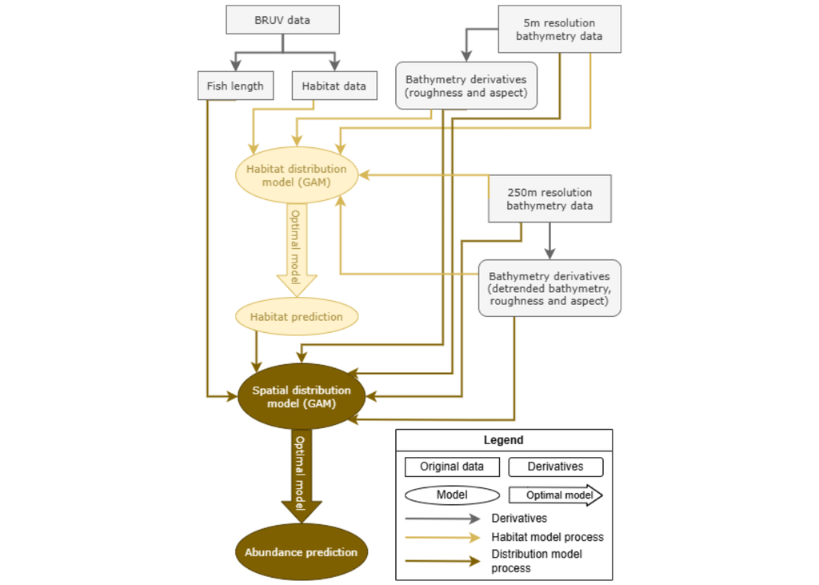

(#fig:distribution_model_diagram)Diagram of the species distribution model process

#### 2.2.3.2 Simulated NTZ

To test the ability of each sampling design to detect a true increase in Yijarup/Pink Snapper abundance in NTZs, a simulated NTZ was designed in Waatern/Geographe Bay (Fig. @ref(fig:example_sampling_design)). The location and size of the NTZ was chosen to be representative and realistic compared to existing NTZs in the area. The chosen area encompasses a reef feature along the coastline, which is protected by the East Geographe NTZs further southwest of the bay.

The mean and standard errors of the predicted Yijarup/Pink Snapper abundance were increased uniformly by 80% within the NTZ to simulate a moderate ‘MPA effect’ on this recreational target species, as had been found for Yijarup/Pink Snapper by Harasti et al. (2018).

#### 2.2.3.3 Sampling design simulation

The sampling design simulations were conducted in an area covering 223.5 km<sup>2</sup>, including ~86.1 km<sup>2</sup> of NTZ and ~68.7 km<sup>2</sup> on either side of the simulated NTZ (@red(fig:example_sampling_design). This aims to mimic the subsample of BRUVs analysed for community composition. Areas shallower than 7m were excluded, as these are rarely targeted in real BRUV campaigns. Three sampling designs were simulated to emulate real BRUV sampling conducted in Waatern/Geographe Bay:

##### 2.2.3.3.1 a. Spatially Balanced Sampling Design

The spatially balanced sampling design was created by categorising the 250m detrended bathymetry raster layer into 3 strata (based on quantiles values, (@ref(tab:n_sample_table)), then randomly distributing a set number of sample points into each stratum. The number of sample points were decided to approach the number of samples collected in 2024 in a comparable area (@ref(tab:n_sample_table)). Sample points were placed using the Generalised Random Tessellation Stratified (GRTS) sampling function from the spsurvey package in R (Dumelle et al. 2023). The minimum distance between points was set to 500m to reduce spatial autocorrelation. Detrended bathymetry was considered to be most appropriate to use for the stratification as it encompassed the study site’s seabed features better than bathymetry, aspect or roughness. The GRTS sampling function was iterated 1000 times to obtain a set of simulated spatially balanced sampling designs.

##### 2.2.3.3.2 b. Preferential Sampling Design

Samples were randomly distributed on the highest quantile of detrended bathymetry (Strata 3, Table @ref(n_samples_table)), to mimic the preferential approach of real sampling. The number of samples per strata were decided based on the number of samples from a comparable area in the BRUV campaign of this paper (Table @ref(n_samples_table)). The number of samples were then distributed using Generalised Random Tessellation Stratified (GRTS) sampling function from the spsurvey package in R (Dumelle et al. 2023). This method was iterated 1000 times to obtain a set of simulated preferential sampling designs.

#### 2.2.3.4 c. Clustered Sampling Design

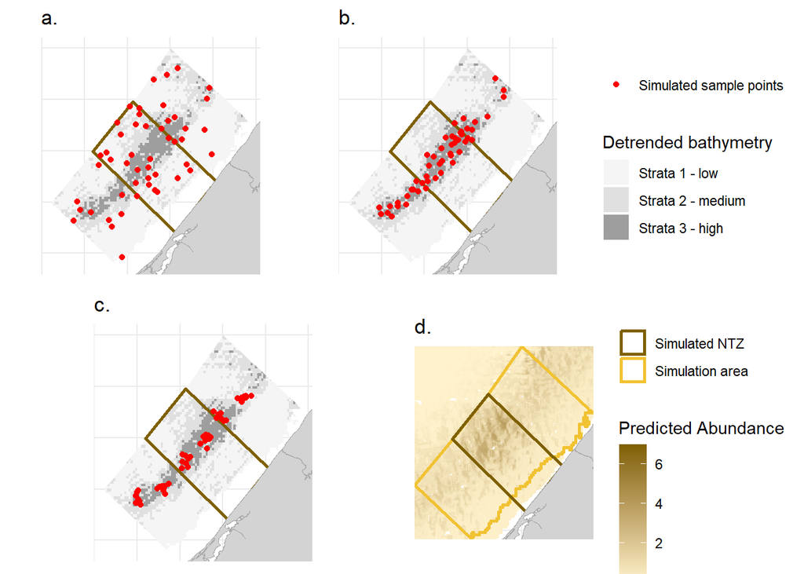

(#fig:example_sampling_design)Examples of a. Spatially balanced sampling design simulation, b. Preferential sampling design simulation and c. clustered sampling design simulation around the simulated NTZ. D. Predicted abundance around the simulation area with 80% increase in C. auratus within the simulated NTZ.

#### 2.2.3.5 Analysis of simulation

Values of abundance were obtained from the latitude and longitude of the 50 simulated points of each of the 3000 simulations. To account for the biological variability of Yijarup/Pink Snapper, and the uncertainty associated with detecting *x* individuals consistently where *x* individuals are predicted to be, each sampling point could observe one abundance value within the Normal distribution of abundance of that raster pixel (rnorm function in base R). For each sampling design, two comparisons were made:

- Control-Impact (CI) comparison: The ratio of the mean abundance of Yijarup/Pink Snapper inside and outside the simulated NTZ after the abundance increase. This replicates a common monitoring strategy where the effect of the MPA is assessed by comparing the metric of interest in the MPA site (Impact) to that of a similar non-protected site (Control). (Equation 1) (Underwood 1991)

$$R_{\text{CI}} = \frac{\mu_{\text{NTZ, after}}}{\mu_{\text{fished}}} \tag{1}$$

- Before-After-Control-Impact (BACI) comparison: The difference of the ratios of the mean abundance of Yijarup/Pink Snapper inside and outside the simulated NTZ, before and after the abundance increase. This replicates the monitoring strategy outlined by Underwood (1991), where the impact of an MPA can be better described by using NTZ sites (Impact) and unprotected sites (Control), over time (Equation 2).

$$R_{\text{BACI}} = \frac{\mu_{\text{NTZ, after}} - \mu_{\text{NTZ, before}}}{\mu_{\text{fished}}} \tag{2}$$

# 3 Results

A total of 283 BRUV samples were collected, including 47 preferential and 236 spatially balanced samples (Table @ref(tab:n_samples_table)). A total of 184 species were detected in samples, including 56 species identified to the Genus or Family level and 128 species identified to the species level. Certain species with very similar appearance (=difficult to identify/differentiate with certainty) were grouped together to form a complex, and are considered as one species.

Within the yellow box specified in Fig. @ref(fig:example_sampling_design), 18 preferential samples were collected inside the NTZ, and 29 were collected outside. In the same area, 27 spatially balanced samples were collected inside the NTZ, and 25 were collected outside the NTZ.

## 3.1 Effect of sampling design on the detection of community composition differences around a NTZ

Manyglm model

[output not shown]

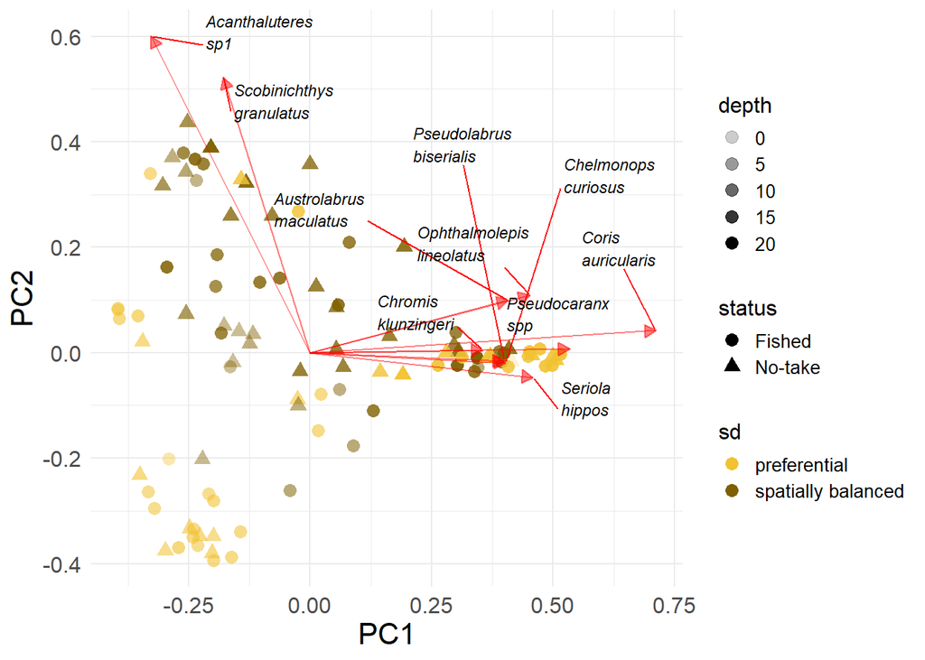

(#fig:PCoA_plot)Principal Composite Analysis of community composition. Species vectors in red represent species with a correlation > 0.35.

The PCoA and manyglm model highlighted differences in fish community composition between the two sampling designs (Figure @ref(fig:PCoA_plot)). Community composition was significantly different between sampling design. A total of 10 species drove the pattern in the PCoA (correlation > 0.35) (Figure @ref(fig:PCoA_plot)). The effect of NTZ on community composition was not significant (Table @ref(tab:manyglm_output_table)).

## 3.2 Effect of sampling design on the detection of the NTZ effect of a single species

(#tab:gam_table)Generalised Additive model of *C.auratus* abundance

| Variable | Estimate | Std. Error | t value | Pr(>\|t\|) |
| --- | --- | --- | --- | --- |
| Detrended bathymetry (250m resolution) | 1.001 | 1.002 | 1.667 | 0.197 |
| Reef (250m resolution) | 1.789 | 1.955 | 51.260 | 0.000 |
| Sand (250m resolution) | 1.941 | 1.996 | 27.136 | 0.000 |

| SD | Before Fished | Before No-take | After Fished | After No-Take |
| --- | --- | --- | --- | --- |
| clump | 0.997 | 0.971 | 0.996 | 1.750 |
| Preferential | 0.947 | 1.036 | 0.950 | 1.865 |
| Spatially Balanced | 0.749 | 0.751 | 0.751 | 1.359 |

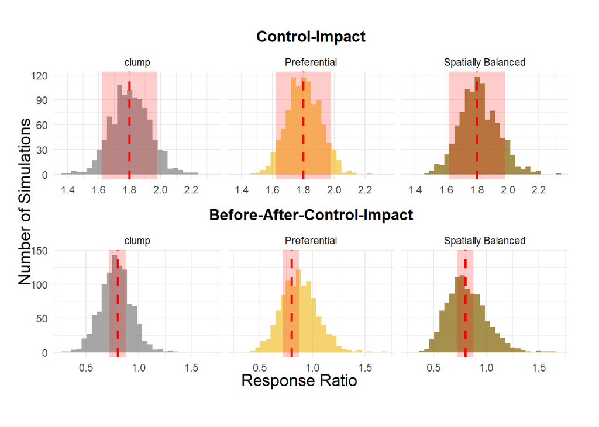

(#fig:ratio_barplot)Histogram of the Control-Impact (CI) and Before-After-Control-Impact (BACI) comparisons. The red dashed line indicates the true ratio (1.8 for CI, and 0.8 for BACI), and the red box indicates 10% either side of the true ratio.

### 3.2.1 Spatially balanced sampling design performance

In the CI comparison, the ratio in the modelled abundance ratio of Yijarup/Pink Snapper inside and outside the simulated NTZ was underestimated in 5.1% and overestimated in 9.9% of spatially balanced simulations. In the BACI comparison, the difference in the modelled abundance ratio of Yijarup/Pink Snapper inside and outside the simulated NTZ before and after the abundance increase was underestimated in 31.5% and overestimated in 33.8% of spatially balanced simulations. (Figure @ref(fig:ratio_barplot))

### 3.2.2 Preferential sampling design performance

In the CI comparison, the ratio in the modelled abundance ratio of Yijarup/Pink Snapper inside and outside the simulated NTZ was underestimated in 4.3% and overestimated in 5.9% of preferential simulations. In the BACI comparison, the difference in the modelled abundance ratio of Yijarup/Pink Snapper inside and outside the simulated NTZ before and after the abundance increase was underestimated in 17.3% and overestimated in 47.8% of preferential simulations. (Figure @ref(fig:ratio_barplot))

# 4 Discussion

In this study, the performance of preferential and spatially balanced BRUV sampling designs are compared as MPA monitoring tools for single species detection and community composition at the local scale. Results highlight the importance of sampling design choice for BRUV studies, and how both designs may under- or over-estimate the effects of NTZs on single target species such as Yijarup/Pink Snapper at this scale.

## 4.1 Community composition

The significant difference in community composition between sampling designs is not surprising, as the spacing and distribution of points within the sampling area is quite different between the two. The habitat association of communities, and the variety of habitat across the sampling area likely means that the preferential design sampled a restricted range of habitat, thus detecting this habitat’s community very well. In contrast, the spatially balanced design may have sampled a wider range of habitats, detecting the whole sampling area’s community well overall, but individual habitats’ communities less thoroughly. Alessi et al. (2023) found the same conclusions when simulating the performance of preferential and probabilistic sampling designs on vegetation communities. They found that preferential sampling detected ‘habitat specialist species’ better, but the probabilistic sampling design detected the richness and diversity of the study area better. This could be roughly summarised as a difference in number of samples per habitat, which alters the accuracy of estimates in population ecology (Stockwell and Peterson 2002). In multivariate community composition analyses like the present study, sample size is just as important, as trends for multiple species must be detected: Irvine, Dinger, and Sarr (2011) simulated the detection ability of different multivariate tests on community composition, and found that sample size had a large effect on trend detection, regardless of the community trend (increasing/decreasing and mixed trend) or the multivariate test.

As a result, a choice must be made between sampling a single habitat very well (like the preferential design) or capturing more habitats perhaps less well (like the spatially balanced design). In the context of MPA monitoring, the added challenge of placing samples so that the effect of the MPA can be assessed correctly complicates things. On a local scale, habitats are heterogeneous and MPAs may be placed to optimise conservation outcomes (= on attractive and biodiverse features, not necessarily representing all habitats at this scale, Stevens and Connolly (2005)), or avoid fishing grounds (= on areas less threatened or less biodiverse, described as ‘low hanging fruit’ by Agardy, Di Sciara, and Christie (2011)). Measuring the effect of an MPA on community composition using preferential sampling would require the same features to exist inside and outside the MPA, or an identical unprotected site to be sampled to pair with the MPA site, which is rarely possible, and rarely done in studies (Osenberg et al. 2006; Underwood 1991). Comparatively, spatially balancing samples allows for the categorisation of the area not in features, but in geomorphology (or other environmental variable) strata, which can be more even and spatially representative in the distribution of samples, and allow the assessment of an MPA effect.

## 4.3 Implication

Agardy, Tundi, Giuseppe Notarbartolo Di Sciara, and Patrick Christie. 2011. “Mind the Gap: Addressing the Shortcomings of Marine Protected Areas Through Large Scale Marine Spatial Planning.” *Marine Policy* 35 (2): 226–32.

Airoldi, Laura, David Balata, and Michael W Beck. 2008. “The Gray Zone: Relationships Between Habitat Loss and Marine Diversity and Their Applications in Conservation.” *Journal of Experimental Marine Biology and Ecology* 366 (1-2): 8–15.

Alessi, N., G. Bonari, P. Zannini, B. Jiménez-Alfaro, E. Agrillo, F. Attorre, and A. Chiarucci. 2023. “Probabilistic and Preferential Sampling Approaches Offer Integrated Perspectives of Italian Forest Diversity.” *Journal of Vegetation Science* 34 (1): e13175.

Alós, J., and R. Arlinghaus. 2013. “Impacts of Partial Marine Protected Areas on Coastal Fish Communities Exploited by Recreational Angling.” *Fisheries Research* 137: 88–96.

Aubry, P., C. Francesiaz, and M. Guillemain. 2024. “On the Impact of Preferential Sampling on Ecological Status and Trend Assessment.” *Ecological Modelling* 492: 110707.

Borja, A., and M. Elliott. 2021. “From an Economic Crisis to a Pandemic Crisis: The Need for Accurate Marine Monitoring Data to Take Informed Management Decisions.” *Advances in Marine Biology* 89: 79–114.

Brown, C. J., M. I. Saunders, H. P. Possingham, and A. J. Richardson. 2013. “Managing for Interactions Between Local and Global Stressors of Ecosystems.” *PloS One* 8 (6): e65765.

Bryan, D. R., S. G. Smith, J. S. Ault, M. W. Feeley, and C. W. Menza. 2016. “Feasibility of a Regionwide Probability Survey for Coral Reef Fish in Puerto Rico and the u.s. Virgin Islands.” *Marine and Coastal Fisheries: Dynamics, Management, and Ecosystem Science* 8 (1): 135–46.

Cameron, M. J., V. Lucieer, N. S. Barrett, C. R. Johnson, and G. J. Edgar. 2014. “Understanding Community-Habitat Associations of Temperate Reef Fishes Using Fine-Resolution Bathymetric Measures of Physical Structure.” *Marine Ecology Progress Series* 506: 213–29.

Cheng, W., C. Zhang, Y. Ji, Y. Xue, Y. Ren, and B. Xu. 2024. “Performance Evaluation of Spatially Balanced Sampling Designs in Fishery-Independent Surveys.” *Fisheries Research* 270: 106879.

Conn, P. B., J. T. Thorson, and D. S. Johnson. 2017. “Confronting Preferential Sampling When Analysing Population Distributions: Diagnosis and Model‐based Triage.” *Methods in Ecology and Evolution* 8 (11): 1535–46.

Davies, H., W. Webb, I. Webb, T. Webb, D. Guilfoyle, S. Clohessy, K. Griffin, and T. Langlois. 2022. “The Cultural Seascape of Wadandi Boodja: The Cultural Values of Australia’s South-West Marine Parks.” https://www.nespmarinecoastal.edu.au/wp-content/uploads/2023/12/Davies_Langlois-et-al_D3_The-Cultural-Seascape-of-Wadandi-Country_Sep2022_Report.pdf.

Dumelle, M., T. Kincaid, A. R. Olsen, and M. Weber. 2023. “Spsurvey: Spatial Sampling Design and Analysis in r.” *Journal of Statistical Software* 105 (3): 1.

Fernández, T. V., G. D’anna, F. Badalamenti, and A. Pérez-Ruzafa. 2008. “Habitat Connectivity as a Factor Affecting Fish Assemblages in Temperate Reefs.” *Aquatic Biology* 1 (3): 239–48.

Fisher, R. 2024. *FSSgam: Full Subsets Multiple Regresssion in r Using Gam(m4)*. https://github.com/beckyfisher/FSSgam_package.

Fisher, R., S. K. Wilson, T. M. Sin, A. C. Lee, and T. J. Langlois. 2018. “A Simple Function for Full‐subsets Multiple Regression in Ecology with r.” *Ecology and Evolution* 8 (12): 6104–13.

Foster, S. D., J. Monk, E. Lawrence, K. R. Hayes, G. R. Hosack, and R. Przeslawski. 2018. “Statistical Considerations for Monitoring and Sampling.” In *Field Manuals for Marine Sampling to Monitor Australian Waters*, 1:23–41.

Galaiduk, R., R. Nanson, Z. Huang, S. Nichol, and K. Miller. 2018. “An Eco-Narrative of Geographe Marine Park – South-West Marine Region.” https://www.researchgate.net/profile/Ronen-Galaiduk/publication/330409162_An_eco-narrative_of_Geographe_Marine_Park_South-west_marine_region_Report_to_the_National_Environmental_Science_Programme_Marine_Biodiversity_Hub_Geoscience_Australia/links/5c3e83f392851c22a3785da6/An-eco-narrative-of-Geographe-Marine-Park-South-west-marine-region-Report-to-the-National-Environmental-Science-Programme-Marine-Biodiversity-Hub-Geoscience-Australia.pdf.

Gaynor, A., A. Kendrick, and M. Westera. 2008. “An Oral History of Fishing and Diving in the Capes Region of South-West Western Australia.”

Gissi, E., E. Manea, A. D. Mazaris, S. Fraschetti, V. Almpanidou, S. Bevilacqua, M. Coll, et al. 2021. “A Review of the Combined Effects of Climate Change and Other Local Human Stressors on the Marine Environment.” *The Science of the Total Environment* 755: 142564.

Harasti, D., T. R. Davis, A. Jordan, L. Erskine, and N. Moltschaniwskyj. 2019. “Illegal Recreational Fishing Causes a Decline in a Fishery Targeted Species (Snapper: Chrysophrys Auratus) Within a Remote No-Take Marine Protected Area.” *PloS One* 14 (1): e0209926.

Harasti, D., J. Williams, E. Mitchell, S. Lindfield, and A. Jordan. 2018. “Increase in Relative Abundance and Size of Snapper Chrysophrys Auratus Within Partially-Protected and No-Take Areas in a Temperate Marine Protected Area.” *Frontiers in Marine Science* 5: 334780.

Hayes, K. R., G. R. Hosack, E. Lawrence, P. Hedge, N. S. Barrett, R. Przeslawski, M. J. Caley, and S. D. Foster. 2019. “Designing Monitoring Programs for Marine Protected Areas Within an Evidence-Based Decision Making Paradigm.” *Frontiers in Marine Science* 6. https://doi.org/10.3389/fmars.2019.00746.

Heyns-Veale, E. R., A. T. F. Bernard, N. B. Richoux, D. Parker, T. J. Langlois, E. S. Harvey, and A. Götz. 2016. “Depth and Habitat Determine Assemblage Structure of South Africa’s Warm-Temperate Reef Fish.” *Marine Biology* 163: 1–17.

Hijmans, R. J., J. Van Etten, and J. Cheng. 2015. *Package "Raster"*.

Irvine, K. M., E. C. Dinger, and D. Sarr. 2011. “A Power Analysis for Multivariate Tests of Temporal Trend in Species Composition.” *Ecology* 92 (10): 1879–86.

Isbell, Forest, Patricia Balvanera, Akira S Mori, Jin-Sheng He, James M Bullock, Ganga Ram Regmi, Eric W Seabloom, et al. 2023. “Expert Perspectives on Global Biodiversity Loss and Its Drivers and Impacts on People.” *Frontiers in Ecology and the Environment* 21 (2): 94–103.

Kelaher, B. P., M. A. Coleman, A. Broad, M. J. Rees, A. Jordan, and A. R. Davis. 2014. “Changes in Fish Assemblages Following the Establishment of a Network of No-Take Marine Reserves and Partially-Protected Areas.” *PloS One* 9 (1): e85825.

Kermorvant, C., F. D’Amico, N. Bru, N. Caill-Milly, and B. Robertson. 2019. “Spatially Balanced Sampling Designs for Environmental Surveys.” *Environmental Monitoring and Assessment* 191 (8): 524.

Langlois, T., J. Goetze, T. Bond, J. Monk, R. A. Abesamis, J. Asher, N. Barrett, et al. 2020. “A Field and Video Annotation Guide for Baited Remote Underwater Stereo‐video Surveys of Demersal Fish Assemblages.” *Methods in Ecology and Evolution* 11 (11): 1401–9.

Ling, S. D., and C. R. Johnson. 2012. “Marine Reserves Reduce Risk of Climate-Driven Phase Shift by Reinstating Size- and Habitat-Specific Trophic Interactions.” *Ecological Applications: A Publication of the Ecological Society of America* 22 (4): 1232–45.

Liu, Y., Y. Chen, and J. Cheng. 2009. “A Comparative Study of Optimization Methods and Conventional Methods for Sampling Design in Fishery-Independent Surveys.” *ICES Journal of Marine Science* 66 (9): 1873–82.

Luypaert, Thomas, James G Hagan, Morgan L McCarthy, and Meenakshi Poti. 2020. “Status of Marine Biodiversity in the Anthropocene.” In *YOUMARES 9-the Oceans: Our Research, Our Future: Proceedings of the 2018 Conference for YOUng MArine RESearcher in Oldenburg, Germany*, 57–82. Springer International Publishing.

Malcolm, H. A., J. Williams, A. L. Schultz, J. Neilson, N. Johnstone, N. A. Knott, D. Harasti, M. A. Coleman, and A. Jordan. 2018. “Targeted Fishes Are Larger and More Abundant in ‘No-Take’ Areas in a Subtropical Marine Park.” *Estuarine, Coastal and Shelf Science* 212: 118–27.

McCauley, Douglas J, Malin L Pinsky, Stephen R Palumbi, James A Estes, Francis H Joyce, and Robert R Warner. 2015. “Marine Defaunation: Animal Loss in the Global Ocean.” *Science* 347 (6219): 1255641.

Miller, K. I., and G. R. Russ. 2014. “Studies of No-Take Marine Reserves: Methods for Differentiating Reserve and Habitat Effects.” *Ocean & Coastal Management* 96: 51–60.

Miteva, D. A., S. K. Pattanayak, and P. J. Ferraro. 2012. “Evaluation of Biodiversity Policy Instruments: What Works and What Doesn’t?” *Oxford Review of Economic Policy* 28 (1): 69–92.

Monk, Jacquomo, Daniel Ierodiaconou, Alecia Bellgrove, Euan Harvey, and Laurie Laurenson. 2011. “Remotely Sensed Hydroacoustics and Observation Data for Predicting Fish Habitat Suitability.” *Continental Shelf Research* 31 (2): S17–27.

Oksanen, J., F. G. Blanchet, R. Kindt, P. Legendre, P. R. Minchin, R. B. O’hara, and M. Oksanen. 2013. *Package "Vegan." Community Ecology Package*. Vol. 2.

Osenberg, C. W., B. M. Bolker, J. S. S. White, C. M. St Mary, and J. S. Shima. 2006. *Statistical Issues and Study Design in Ecological Restorations: Lessons Learned from Marine Reserves*.

Ovando, Daniel, Jennifer E. Caselle, Christopher Costello, Olivier Deschenes, Steven D. Gaines, Ray Hilborn, and Oliver Liu. 2021. “Assessing the Population‐level Conservation Effects of Marine Protected Areas.” *Conservation Biology* 35 (6): 1861–70. https://doi.org/10.1111/cobi.13794.

Parsons, D. M., D. Buckthought, C. Middleton, and G. MacKay. 2016. “Relative Abundance of Snapper (Chrysophrys Auratus) Across Habitats Within an Estuarine System.” *New Zealand Journal of Marine and Freshwater Research* 50 (3): 358–70.

Pereira, Henrique M, Paul W Leadley, Vânia Proença, Rob Alkemade, Jörn PW Scharlemann, Juan F Fernandez-Manjarrés, Miguel B Araújo, et al. 2010. “Scenarios for Global Biodiversity in the 21st Century.” *Science* 330 (6010): 1496–1501.

Pygas, Daniel R, Renata Ferrari, and Will F Figueira. 2020. “Review and Meta-Analysis of the Importance of Remotely Sensed Habitat Structural Complexity in Marine Ecology.” *Estuarine, Coastal and Shelf Science* 235: 106468.

Robinson, John G, Danielle LaBruna, Tim O’Brien, Peter J Clyne, Nigel Dudley, Sandy J Andelman, Elizabeth L Bennett, et al. 2024. “Scaling up Area-Based Conservation to Implement the Global Biodiversity Framework’s 30x30 Target: The Role of Nature’s Strongholds.” *Plos Biology* 22 (5): e3002613.

Ryan, K. L., C. B. Smallwood, and E. K. Lai. 2022. “Boat-Based Recreational Fishing in Western Australia 2020/21.” Western Australia: Department of Primary Industries; Regional Development.

Schramm, K. D., E. S. Harvey, J. S. Goetze, M. J. Travers, B. Warnock, and B. J. Saunders. 2020. “A Comparison of Stereo-BRUV, Diver Operated and Remote Stereo-Video Transects for Assessing Reef Fish Assemblages.” *Journal of Experimental Marine Biology and Ecology* 524: 151273.

Scott, M. E., S. B. Tebbett, K. L. Whitman, C. A. Thompson, F. B. Mancini, M. R. Heupel, and M. S. Pratchett. 2022. “Variation in Abundance, Diversity and Composition of Coral Reef Fishes with Increasing Depth at a Submerged Shoal in the Northern Great Barrier Reef.” *Reviews in Fish Biology and Fisheries* 32 (3): 941–62.

Simpson, CJ, M Beger, JG Colman, KJ Friedman, AK Hill, AJ Kendrick, KA Waples, SD Whiting, and SK Wilson. 2015. “Prioritisation of Conservation Research and Monitoring for Western Australian Protected Areas and Threatened Species.” *Conservation Science Western Australia* 9 (3): 227–37.

Smith, S. G., J. S. Ault, J. A. Bohnsack, D. E. Harper, J. Luo, and D. B. McClellan. 2011. “Multispecies Survey Design for Assessing Reef-Fish Stocks, Spatially Explicit Management Performance, and Ecosystem Condition.” *Fisheries Research* 109 (1): 25–41.

Stevens, Tim, and Rod M. Connolly. 2005. “Local-Scale Mapping of Benthic Habitats to Assess Representation in a Marine Protected Area.” *Marine and Freshwater Research* 56 (1): 111–23. https://doi.org/10.1071/MF04145.

Stockwell, D. R., and A. T. Peterson. 2002. “Effects of Sample Size on Accuracy of Species Distribution Models.” *Ecological Modelling* 148 (1): 1–13.

Switzer, T. S., S. F. Keenan, K. A. Thompson, C. P. Shea, A. R. Knapp, M. D. Campbell, and M. C. Christman. 2023. “Integrating Assemblage Structure and Habitat Mapping Data into the Design of a Multispecies Reef Fish Survey.” *Marine and Coastal Fisheries* 15 (4): e10245.

Taylor, B. M., and J. L. McIlwain. 2010. “Beyond Abundance and Biomass: Effects of Marine Protected Areas on the Demography of a Highly Exploited Reef Fish.” *Marine Ecology Progress Series* 411: 243–58.

Terres, M. A., E. Lawrence, G. R. Hosack, M. D. E. Haywood, and R. C. Babcock. 2015. “Assessing Habitat Use by Snapper (Chrysophrys Auratus) from Baited Underwater Video Data in a Coastal Marine Park.” *PloS One* 10 (8): e0136799.

Underwood, A. 1991. “Beyond BACI: Experimental Designs for Detecting Human Environmental Impacts on Temporal Variations in Natural Populations.” *Marine and Freshwater Research* 42: 569–87.

Virgili, Auriane, Mélanie Racine, Matthieu Authier, Pascal Monestiez, and Vincent Ridoux. 2017. “Comparison of Habitat Models for Scarcely Detected Species.” *Ecological Modelling* 346: 88–98.

Wakefield, C. B., I. C. Potter, N. G. Hall, R. C. J. Lenanton, and S. A. Hesp. 2015. “Marked Variations in Reproductive Characteristics of Snapper (Chrysophrys Auratus, Sparidae) and Their Relationship with Temperature over a Wide Latitudinal Range.” *ICES Journal of Marine Science: Journal Du Conseil* 72 (8): 2341–49.

Wang, Y. I., U. Naumann, S. T. Wright, and D. I. Warton. 2012. “Mvabund–an r Package for Model-Based Analysis of Multivariate Abundance Data.” *Methods in Ecology and Evolution* 3 (3): 471–74.

Watson, D. L., M. J. Anderson, G. A. Kendrick, K. Nardi, and E. S. Harvey. 2009. “Effects of Protection from Fishing on the Lengths of Targeted and Non-Targeted Fish Species at the Houtman Abrolhos Islands, Western Australia.” *Marine Ecology Progress Series* 384: 241–49.

Watson, D. L., E. S. Harvey, G. A. Kendrick, K. Nardi, and M. J. Anderson. 2007. “Protection from Fishing Alters the Species Composition of Fish Assemblages in a Temperate-Tropical Transition Zone.” *Marine Biology* 152 (5): 1197–1206.

Wood, S. N. 2001. “Mgcv: GAMs and Generalized Ridge Regression for r.” *R News*. https://journal.r-project.org/articles/RN-2001-015/RN-2001-015.pdf.

Zhao, Chang, Yuejing Ge, and Miaozhuang Zheng. 2024. “Reflections on How to Reach the ‘30 by 30’ Target: Identification of and Suggestions on Global Priority Marine Areas for Protection.” *Water* 16 (16): 2293.